# R Data Visualization Solutions

Go back to the main page  
Go back to the R overview page

# R

## Data Visualization

```r
library("tidyverse")
```

> The following function is used to print tibbles in a proper way for the web. You can skip the use of this function to print tibbles to your screen in R Markdown documents.

```r
library(knitr)
library(kableExtra)
library(pillar)

formatted_table <- function(df) {
  col_types <- sapply(df, pillar::type_sum)
  new_col_names <- paste0(names(df), "<br>", "<span style='font-weight: normal;'>", col_types, "</span>")
  kbl(df,
      col.names = new_col_names,
      escape = FALSE, # This is crucial to allow the <br> tag to work
      format = "html" # Ensure HTML format, although often auto-detected
      ) %>%
    kable_styling(bootstrap_options = c("striped", "hover", "responsive"))
}
```

This file can be found here.

> The exercises will be similar to the exercises in Excel in order to compare the results.

### Exercise 1

Load the Following dataset.

The data frame shows RNA expression data with and without a stimulus.  
Create a column chart for the `MAP kinase Expression values` without a stimulus with expression levels **higher** than 0.5.  
Annotate the axis and add a proper title.  
Sort the expression values from *low to high* (the graph should contain bars with increasing height).

Which three gene names have the highest Expression Value *without* a stimulus?

```r
# loading data
file_path_ex1 <- "./files_13_data_visualization_exercises/exercise01/expression_data.csv"
df_ex1 <- read_tsv(file_path_ex1)
formatted_table(head(df_ex1))
```

| NM number chr | Gene name chr | Gene Family chr | Category chr | Expression Value - stimulus dbl | Expression Value + stimulus dbl |
| --- | --- | --- | --- | --- | --- |
| NM_0009985 | B3GALT6 | Cyclin dependent kinases | Regulatory protein gene families | 0.403 | 0.420 |
| NM_0007588 | TMEM240 | Cyclin dependent kinases | Regulatory protein gene families | 0.295 | 0.272 |
| NM_0005919 | GNB1 | Kinesin | Motor proteins | 0.267 | 0.263 |
| NM_0003080 | SKI | Protocadherin gene family | Transporters | 0.551 | 0.528 |
| NM_0006269 | PRDM16 | Kruppel-type zinc finger (ZNF) | Regulatory protein gene families | 0.432 | 0.424 |
| NM_0005676 | NPHP4 | Peroxiredoxin | Signal transducing proteins | 0.381 | 0.363 |

```r
df_ex1_filtered <- df_ex1 %>%
  filter(
    `Gene Family` == "MAP Kinase",
    `Expression Value - stimulus` > 0.5
  ) %>%
  arrange(`Expression Value - stimulus`)

formatted_table(head(df_ex1_filtered))
```

| NM number chr | Gene name chr | Gene Family chr | Category chr | Expression Value - stimulus dbl | Expression Value + stimulus dbl |
| --- | --- | --- | --- | --- | --- |
| NM_0003212 | RAB18 | MAP Kinase | Signal transducing proteins | 0.526 | 0.569 |
| NM_0004391 | UCHL1 | MAP Kinase | Signal transducing proteins | 0.542 | 0.580 |
| NM_0002646 | USH2A | MAP Kinase | Signal transducing proteins | 0.546 | 0.557 |
| NM_0006544 | PTCHD1 | MAP Kinase | Signal transducing proteins | 0.562 | 0.587 |
| NM_0005952 | FOXI1 | MAP Kinase | Signal transducing proteins | 0.563 | 0.588 |
| NM_0002036 | NDUFA10 | MAP Kinase | Signal transducing proteins | 0.599 | 0.650 |

Create the plot:

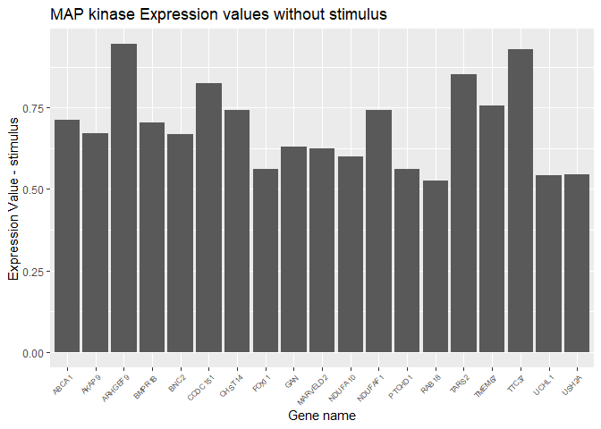

```r
p <- ggplot(data = df_ex1_filtered, aes(x = `Gene name`, y = `Expression Value - stimulus`)) +
  geom_bar(stat = "identity") +
  labs(title="MAP kinase Expression values without stimulus") +
  theme(axis.text.x = element_text(angle = 45, hjust=1, size=6))
p
```

TARS2, TTC37 and ARHGEF9 have the highest expression value *without* a stimulus.

### Exercise 2

From the previous data set, use again the gene expression within the `MAP Kinase gene family`.  
Create a **clustered column chart** representing the expression values without stimulus and the expression values with stimulus. Make sure to add proper axis titles, a title and a legend.

First we create a data frame with the rows of MAP kinases:

```r
df_ex2 <- df_ex1[str_detect(df_ex1$`Gene Family`, "MAP Kinase"), ]
formatted_table(head(df_ex2))
```

| NM number chr | Gene name chr | Gene Family chr | Category chr | Expression Value - stimulus dbl | Expression Value + stimulus dbl |
| --- | --- | --- | --- | --- | --- |
| NM_0003248 | PINK1 | MAP Kinase | Signal transducing proteins | 0.017 | 0.017 |
| NM_0002646 | USH2A | MAP Kinase | Signal transducing proteins | 0.546 | 0.557 |
| NM_0002036 | NDUFA10 | MAP Kinase | Signal transducing proteins | 0.599 | 0.650 |
| NM_0009299 | FOXP1 | MAP Kinase | Signal transducing proteins | 0.145 | 0.149 |
| NM_0004391 | UCHL1 | MAP Kinase | Signal transducing proteins | 0.542 | 0.580 |
| NM_0001318 | LRIT3 | MAP Kinase | Signal transducing proteins | 0.222 | 0.200 |

Make the data frame tidy:

```r
tidy_df_ex2 <- df_ex2 %>%
  pivot_longer(c(`Expression Value - stimulus`, `Expression Value + stimulus`), names_to = "Expression type", values_to = "Expression Value")
formatted_table(head(tidy_df_ex2))
```

| NM number chr | Gene name chr | Gene Family chr | Category chr | Expression type chr | Expression Value dbl |
| --- | --- | --- | --- | --- | --- |
| NM_0003248 | PINK1 | MAP Kinase | Signal transducing proteins | Expression Value - stimulus | 0.017 |
| NM_0003248 | PINK1 | MAP Kinase | Signal transducing proteins | Expression Value + stimulus | 0.017 |
| NM_0002646 | USH2A | MAP Kinase | Signal transducing proteins | Expression Value - stimulus | 0.546 |
| NM_0002646 | USH2A | MAP Kinase | Signal transducing proteins | Expression Value + stimulus | 0.557 |
| NM_0002036 | NDUFA10 | MAP Kinase | Signal transducing proteins | Expression Value - stimulus | 0.599 |
| NM_0002036 | NDUFA10 | MAP Kinase | Signal transducing proteins | Expression Value + stimulus | 0.650 |

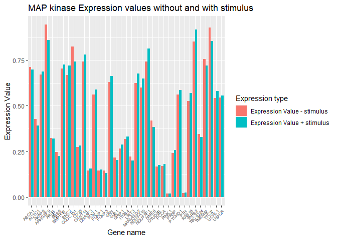

```r
p <- ggplot(data = tidy_df_ex2, aes(x = `Gene name`, y = `Expression Value`, fill = `Expression type`)) +
  geom_bar(stat = "identity", position="dodge") +
  labs(title="MAP kinase Expression values without and with stimulus") +
  theme(axis.text.x = element_text(angle = 45, hjust=1, size=6))
p
```

### Exercise 3

Use the same data as from exercise 2 to create a stacked column chart in which each column represents a gene family from the motor proteins (i.e. dynein, kinesin and myosin) and the segments within each column show the number of genes whose expression is increased or decrease in the presence of the stimulus. Before you can create this chart, you need to analyse the data: - Create a new column, with an appropriate name, in which you use the IF-function to indicate for each gene family whether the expression is increased or decreased. - In a new sheet, use the COUNTIFS-function to count for each motor protein gene family the number of genes whose expression is increased or decreased in the presence of the stimulus. For example (the values in this table are not correct)

| Protein | Increased | Decreased |
| --- | --- | --- |
| Dynein | 6 | 7 |
| Kinesin | 11 | 3 |
| Myosin | 4 | 12 |

First add the extra column and determine if the expression level is up or down:

```r
df_ex1 <- df_ex1 %>%
  mutate(
    up_down = if_else(
      `Expression Value + stimulus` > `Expression Value - stimulus`,
      "UP",
      "DOWN"
    )
  )
formatted_table(head(df_ex1))
```

| NM number chr | Gene name chr | Gene Family chr | Category chr | Expression Value - stimulus dbl | Expression Value + stimulus dbl | up_down chr |
| --- | --- | --- | --- | --- | --- | --- |
| NM_0009985 | B3GALT6 | Cyclin dependent kinases | Regulatory protein gene families | 0.403 | 0.420 | UP |
| NM_0007588 | TMEM240 | Cyclin dependent kinases | Regulatory protein gene families | 0.295 | 0.272 | DOWN |
| NM_0005919 | GNB1 | Kinesin | Motor proteins | 0.267 | 0.263 | DOWN |
| NM_0003080 | SKI | Protocadherin gene family | Transporters | 0.551 | 0.528 | DOWN |
| NM_0006269 | PRDM16 | Kruppel-type zinc finger (ZNF) | Regulatory protein gene families | 0.432 | 0.424 | DOWN |
| NM_0005676 | NPHP4 | Peroxiredoxin | Signal transducing proteins | 0.381 | 0.363 | DOWN |

And now we count the number of genes whose expression is increased or decreased in the presence of the stimulus for each motor protein gene family member.

```r
df_ex4 <- df_ex1 %>%
  filter(Category == "Motor proteins") %>%
  count(`Gene Family`, up_down)
formatted_table(df_ex4)
```

| Gene Family chr | up_down chr | n int |
| --- | --- | --- |
| Dynein | DOWN | 16 |
| Dynein | UP | 11 |
| Kinesin | DOWN | 16 |
| Kinesin | UP | 24 |
| Myosin | DOWN | 17 |
| Myosin | UP | 11 |

Note that the data is already in Tidy format.  
And we can now create the stacked column chart:

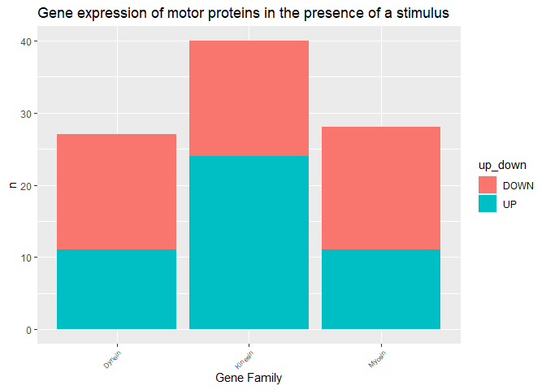

```r
p <- ggplot(data = df_ex4, aes(x = `Gene Family`, y = n, fill = up_down)) +
  geom_bar(stat = "identity", position="stack") +
  labs(title="Gene expression of motor proteins in the presence of a stimulus") +
  theme(axis.text.x = element_text(angle = 45, hjust=1, size=6))
p
```

### Exercise 4

Use the same data as from exercise 3 to create a relative stacked column chart in which each column represents a gene family from the motor proteins (i.e. dynein, kinesin and myosin) and the segments within each column percentage of genes whose expression is increased or decreased in the presence of the stimulus. Make sure to add proper axis titles, a title and a legend. The gene names should be sorted.

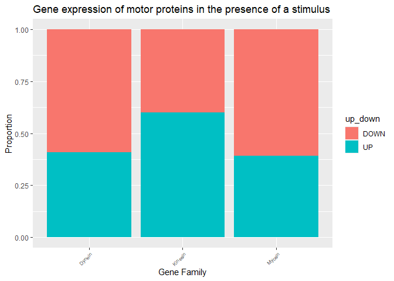

```r
p <- ggplot(data = df_ex4, aes(x = `Gene Family`, y = n, fill = up_down)) +
  geom_bar(stat = "identity", position="fill") +
  labs(title="Gene expression of motor proteins in the presence of a stimulus", x = "Gene Family", y = "Proportion") +
  theme(axis.text.x = element_text(angle = 45, hjust=1, size=6))
p
```

### Exercise 5

In the dataset, each protein belongs to a gene family, and each gene family is classified under a particular category. Create a pie chart representing the contribution of the different gene families within the category “Immuno system proteins”.

- Before creating the chart, analyze the data in R:
- Filter the data: Subset the dataset to keep only the entries belonging to the “Immune system proteins” category.
- Summarize the counts: Determine the unique gene families in this subset and count the number of genes in each family.

Generate the chart: Map the aggregated counts to a polar bar chart in ggplot2 to display the pie chart.

```r
df_ex5 <- df_ex1 %>%
  filter(`Category` == "Immune system proteins") %>%
  count(`Gene Family`)
formatted_table(df_ex5)
```

| Gene Family chr | n int |
| --- | --- |
| Immunoglobulin superfamily | 28 |
| Killer-cell immunoglobulin-like receptors | 30 |
| Leukocyte immunoglobulin-like receptors | 27 |
| Major histocompatibility complex (MHC) | 30 |
| NOD-like receptors | 31 |
| Pattern recognition receptor | 30 |
| RIG-I like receptors | 48 |
| Toll-like receptors | 24 |

And now we can create the Pie chart:

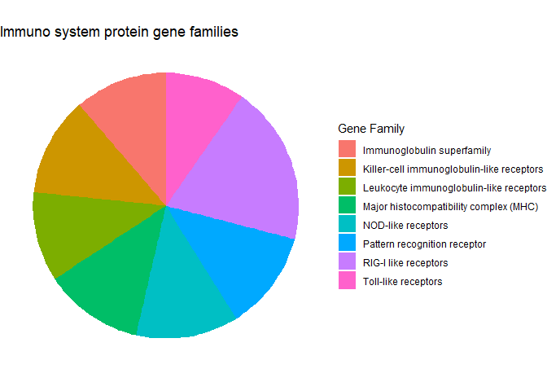

```r
p <- df_ex5 %>%
  ggplot(aes(x = "", y = n, fill = `Gene Family`)) +
  geom_bar(stat="identity", width=1) +
  coord_polar("y", start=0) +
  labs(title="Immuno system protein gene families") +
  theme_void() # remove background, grid, numeric labels
p
```

### Exercise 6

For this exercise you will use the same data.  
Create a **box plot** for Expression value without stimulus plotted against the `Categories`.

Which category shows the *lowest* median value?

Create Box plot:

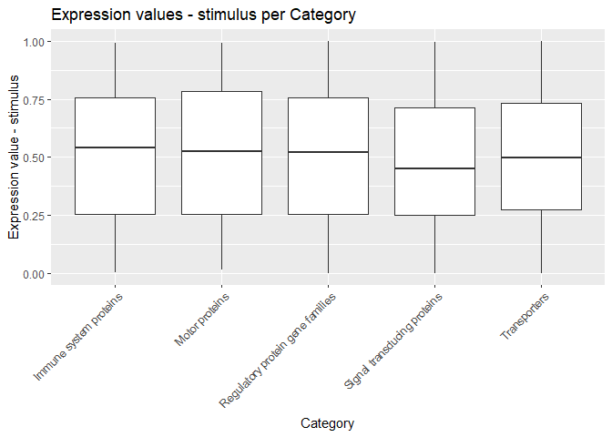

```r
p <- ggplot(df_ex1, aes(x = `Category`, y = `Expression Value - stimulus`)) +
  geom_boxplot() +
  labs(title="Expression values - stimulus per Category") +
  theme(axis.text.x = element_text(angle = 45, hjust=1)) +
  ylab("Expression value - stimulus") +
  xlab("Category")
p
```

The `Signal transducing proteins` have the *lowest* median for Expression Value without stimulus.

### Exercise 7

For this exercise you will use the same data.  
Create a **grouped box plot** for `Expression value without stimulus` vs `Expression Value with stimulus`.

Which category shows the *lowest* IQR value?

This time, you will have to use the tidy data.

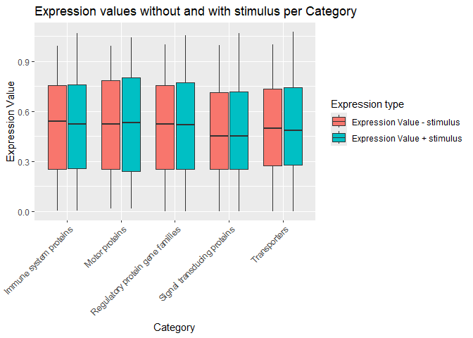

```r
# make data tidy
tidy_df_ex7 <- df_ex1 %>%
  pivot_longer(c(`Expression Value - stimulus`, `Expression Value + stimulus`), names_to = "Expression type", values_to = "Expression Value")

p <- ggplot(tidy_df_ex7, aes(x = `Category`, y = `Expression Value`, fill = `Expression type`)) +
  geom_boxplot() +
  labs(title="Expression values without and with stimulus per Category") +
  theme(axis.text.x = element_text(angle = 45, hjust=1)) +
  ylab("Expression Value") +
  xlab("Category")
p
```

The `Signal transducing proteins` show the *lowest* IQR (lowest height of the Whisker box).

### Exercise 8

In this dataset you can find Chick Weight data. It shows the weight (in grams) on day 42 for various chickens that were fed with various diets during 42 days.

Create a **radar chart** for the various diets on day 42.  
Calculate the average weight per diet.

Two Chickens on a certain diet clearly gained the most weight.  
Which two chickens on which diet generated the highest weight gains?

```r
file_path <- "./files_13_data_visualization_exercises/exercise08/ChickWeight.csv"
df_ex8 <- read_tsv(file_path)
df_ex8 <- rename(df_ex8, `Diet` = `...1`)
formatted_table(df_ex8)
```

| Diet chr | Chick 1 dbl | Chick 2 dbl | Chick 3 dbl | Chick 4 dbl | Chick 5 dbl | Chick 6 dbl | Chick 7 dbl | Chick 8 dbl | Chick 9 dbl |
| --- | --- | --- | --- | --- | --- | --- | --- | --- | --- |
| Diet 1 | 205 | 215 | 202 | 157 | 223 | 157 | 305 | 98 | 124 |
| Diet 2 | 331 | 167 | 175 | 74 | 265 | 251 | 192 | 233 | 309 |
| Diet 3 | 256 | 305 | 147 | 341 | 373 | 220 | 178 | 290 | 272 |
| Diet 4 | 204 | 281 | 200 | 196 | 238 | 205 | 322 | 237 | 264 |

> If you do not have the `ggradar` module installed yet, run the following code to install the module:

```
install.packages("remotes")
remotes::install_github("ricardo-bion/ggradar")
```

```r
library(ggradar)
```

For a radar chart we need to scale the data from 0-1

```r
df_ex8_scaled <- df_ex8[, -1]/400
formatted_table(df_ex8_scaled)
```

| Chick 1 dbl | Chick 2 dbl | Chick 3 dbl | Chick 4 dbl | Chick 5 dbl | Chick 6 dbl | Chick 7 dbl | Chick 8 dbl | Chick 9 dbl |
| --- | --- | --- | --- | --- | --- | --- | --- | --- |
| 0.5125 | 0.5375 | 0.5050 | 0.3925 | 0.5575 | 0.3925 | 0.7625 | 0.2450 | 0.3100 |
| 0.8275 | 0.4175 | 0.4375 | 0.1850 | 0.6625 | 0.6275 | 0.4800 | 0.5825 | 0.7725 |
| 0.6400 | 0.7625 | 0.3675 | 0.8525 | 0.9325 | 0.5500 | 0.4450 | 0.7250 | 0.6800 |
| 0.5100 | 0.7025 | 0.5000 | 0.4900 | 0.5950 | 0.5125 | 0.8050 | 0.5925 | 0.6600 |

Grab the first column:

```r
first_col <- df_ex8[, 1]
formatted_table(first_col)
```

| Diet chr |
| --- |
| Diet 1 |
| Diet 2 |
| Diet 3 |
| Diet 4 |

And add together:

```r
df_ex8_mod <- cbind(first_col, df_ex8_scaled)
formatted_table(df_ex8_mod)
```

| Diet chr | Chick 1 dbl | Chick 2 dbl | Chick 3 dbl | Chick 4 dbl | Chick 5 dbl | Chick 6 dbl | Chick 7 dbl | Chick 8 dbl | Chick 9 dbl |
| --- | --- | --- | --- | --- | --- | --- | --- | --- | --- |
| Diet 1 | 0.5125 | 0.5375 | 0.5050 | 0.3925 | 0.5575 | 0.3925 | 0.7625 | 0.2450 | 0.3100 |
| Diet 2 | 0.8275 | 0.4175 | 0.4375 | 0.1850 | 0.6625 | 0.6275 | 0.4800 | 0.5825 | 0.7725 |
| Diet 3 | 0.6400 | 0.7625 | 0.3675 | 0.8525 | 0.9325 | 0.5500 | 0.4450 | 0.7250 | 0.6800 |
| Diet 4 | 0.5100 | 0.7025 | 0.5000 | 0.4900 | 0.5950 | 0.5125 | 0.8050 | 0.5925 | 0.6600 |

And now we can create the plot:

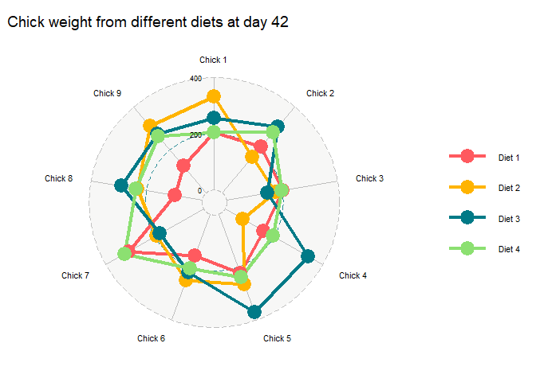

```r
p <- ggradar(df_ex8_mod,  legend.text.size = 8, values.radar = c("0", "200", "400"), axis.label.size = 3, grid.label.size = 3, legend.position = "right") +
  labs(title = "Chick weight from different diets at day 42") +
  theme(plot.title = element_text(size = 14, ))
p
```

Chick 4 and 5 gained the highest weight (on Diet 3).

### Exercise 9

Have look at the data here It contains data about Potassium and Sodium concentrations (in mmol/L) as well as body weight (in kg) for various persons.

Create a **bubble chart** with the Na concentration as a function of the K concentration.  
The bubble size should be based on the body weight.

As you can see, there is a correlation between the sodium and potassium concentration but there is one person who can be considered an outlier. What is the name of this person?

```r
file_path <- "./files_13_data_visualization_exercises/exercise09/data.csv"
df_ex9 <- read_csv(file_path)
formatted_table(head(df_ex9))
```

| Person chr | Potassium conc (mmol/L) dbl | Sodium conc (mmol/L) dbl | Body Weight (kg) dbl |
| --- | --- | --- | --- |
| Alice | 3.8 | 140 | 65 |
| Bob | 4.2 | 138 | 80 |
| Charlie | 3.5 | 145 | 55 |
| David | 4.5 | 135 | 90 |
| Eve | 3.9 | 142 | 70 |
| Frank | 4.1 | 139 | 85 |

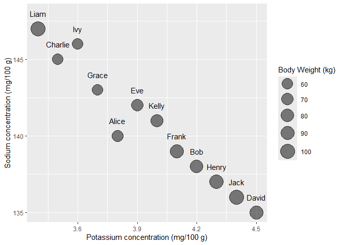

```r
p <- ggplot(df_ex9, aes(x = `Potassium conc (mmol/L)`, y = `Sodium conc (mmol/L)`)) +
  geom_point(aes(size = `Body Weight (kg)`), alpha = 0.5) +
  geom_text(aes(label=Person), position = position_nudge(y = 1)) +
  xlab("Potassium concentration (mg/100 g)") +
  ylab("Sodium concentration (mg/100 g)") +
  scale_size_area(max_size=10)
p
```

Alice shows a relatively low concentration of potassium for the sodium concentration (or a relatively low sodium concentration for the potassium concentration).

### Exercise 10

In this dataset, you will find data on the velocity of an enzymatic reaction were obtained by Treloar (1974). The number of counts per minute of radioactive product from the reaction was measured as a function of substrate concentration in parts per million (ppm) and from these counts the initial rate (or velocity) of the reaction was calculated (counts/min). The experiment was conducted once with the enzyme treated with Puromycin, and once with the enzyme untreated.

Create a **XY-scatter plot** with the velocity plotted against the substrate concentration.

Create a **XY-scatter plot** for the experiment without puromycin and an additional **XY scatter plot** for both (with and without puromycin) conditions.

Does puromycin act as an inhibitor or an activator for this enzyme?

```r
file_path <- "./files_13_data_visualization_exercises/exercise10/puromycin.csv"
df_ex10 <- read_csv(file_path)
colnames(df_ex10) <- c("Substrate concentration (ppm)", "Rate (counts/min)", "State")
formatted_table(head(df_ex10))
```

| Substrate concentration (ppm) dbl | Rate (counts/min) dbl | State chr |
| --- | --- | --- |
| 0.02 | 76 | treated |
| 0.02 | 47 | treated |
| 0.06 | 97 | treated |
| 0.06 | 107 | treated |
| 0.11 | 123 | treated |
| 0.11 | 139 | treated |

Filter the data to be used:

```r
df_ex10_untreated <- df_ex10 %>%
  filter(State == "untreated")
formatted_table(head(df_ex10_untreated))
```

| Substrate concentration (ppm) dbl | Rate (counts/min) dbl | State chr |
| --- | --- | --- |
| 0.02 | 67 | untreated |
| 0.02 | 51 | untreated |
| 0.06 | 84 | untreated |
| 0.06 | 86 | untreated |
| 0.11 | 98 | untreated |
| 0.11 | 115 | untreated |

Create the plot without puromycin:

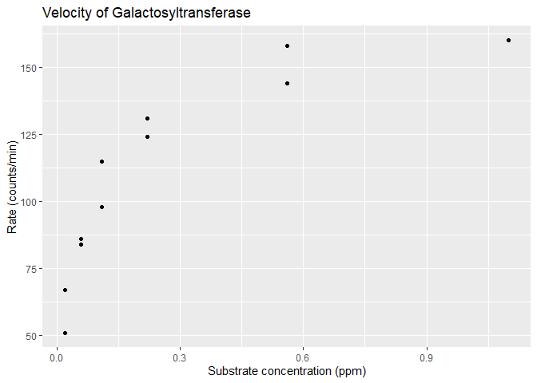

```r
p <- ggplot(data= df_ex10_untreated, aes(x = `Substrate concentration (ppm)`, y = `Rate (counts/min)`)) +
  geom_point() +
  labs(title="Velocity of Galactosyltransferase")
p
```

Or with and without puromycin (just the data points):

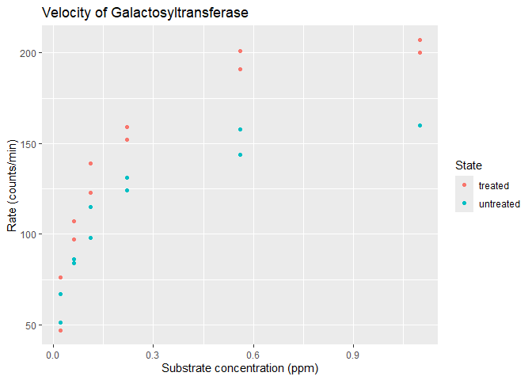

```r
p <- ggplot(data= df_ex10, aes(x = `Substrate concentration (ppm)`, y = `Rate (counts/min)`)) +
  geom_point(aes(color = `State`)) +
  labs(title="Velocity of Galactosyltransferase")
p
```

Puromycin acts as an activator. The measured values of the treated condition are higher than those of the untreated condition.

### Exercise 11

For this exercise, we will use the data set from an earlier exercise again. This time, create a **pivot table** and **pivot plot**.

Download the data set.

Create a **pivot plot** for the *mean* `Expression Value` plotted against the `Categories` (both with and without stimulus).

What category shows the *lowest* expression values and what category shows the *highest* expression values?

First group the food Categories:

```r
df_ex1_summ <- df_ex1 %>%
  group_by(Category) %>%
  summarize("Mean Expression Value - stimulus" = round(mean(`Expression Value - stimulus`), 3),
            "Mean Expression Value + stimulus" = round(mean(`Expression Value + stimulus`), 3))
formatted_table(head(df_ex1_summ))
```

| Category chr | Mean Expression Value - stimulus dbl | Mean Expression Value + stimulus dbl |
| --- | --- | --- |
| Immune system proteins | 0.506 | 0.506 |
| Motor proteins | 0.516 | 0.518 |
| Regulatory protein gene families | 0.507 | 0.510 |
| Signal transducing proteins | 0.482 | 0.484 |
| Transporters | 0.499 | 0.499 |

Make the data tidy:

```r
tidy_df_ex11 <- df_ex1_summ %>%
  pivot_longer(c(`Mean Expression Value - stimulus`, `Mean Expression Value + stimulus`), names_to = "Expression type", values_to = "Expression Value")
formatted_table(head(tidy_df_ex11))
```

| Category chr | Expression type chr | Expression Value dbl |
| --- | --- | --- |
| Immune system proteins | Mean Expression Value - stimulus | 0.506 |
| Immune system proteins | Mean Expression Value + stimulus | 0.506 |
| Motor proteins | Mean Expression Value - stimulus | 0.516 |
| Motor proteins | Mean Expression Value + stimulus | 0.518 |
| Regulatory protein gene families | Mean Expression Value - stimulus | 0.507 |
| Regulatory protein gene families | Mean Expression Value + stimulus | 0.510 |

And now we can create the plot:

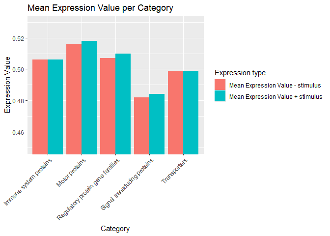

```r
p <- ggplot(data = tidy_df_ex11, aes(x = `Category`, y = `Expression Value`, fill = `Expression type`)) +
  geom_bar(stat = "identity", position = "dodge") +
  labs(title = "Mean Expression Value per Category") +
  coord_cartesian(ylim=c(0.45,0.53)) + # limits of the y-axis were adjusted to compare to the Excel exercise
  theme(axis.text.x = element_text(angle = 45, hjust = 1))
p
```

`Signal transducing proteins` the *lowest* expression values. `Motor proteins` show the *highest* expression levels.

Go back to the main page  
Go back to the R overview page  
⬆️ Back to Top

> This web page is distributed under the terms of the Creative Commons Attribution License which permits unrestricted use, distribution, and reproduction in any medium, provided the original author and source are credited. Creative Commons License: CC BY-SA 4.0.